# Simple Analyzer

7/14/2018

## Simple Analyzer : Overview

- A simple data Analyzer.
- A simple csv file can be uploaded where the first two columns are analyzed.
- The first column holds the response and the second column contains the main predictor feature.
- Access App at :

```r
   https://mtleis.shinyapps.io/simple_analyzer/
```

## Input & Data Viewer

- One the side panel, there is an Input tab, where a file can be uploaded.
- The contents of the first two columns of the input file can be viewed in the Data tab in the main panel.
- When a file is uploaded the histogram and the scatter plot are reactively updated.
- When no file is present. A sample dataset from the default 'trees' data is loaded. The response column is the Volume feature. Main predictor is the Girth feature.

```
##   trees.Volume trees.Girth
## 1         10.3         8.3
## 2         10.3         8.6
## 3         10.2         8.8
## 4         16.4        10.5
## 5         18.8        10.7
## 6         19.7        10.8
```

## Histogram

- In the main panel, Histogram tab shows a histogram of the response feature.
- The number of bins can be controlled via the Slider (located under Slider tab in the side panel).

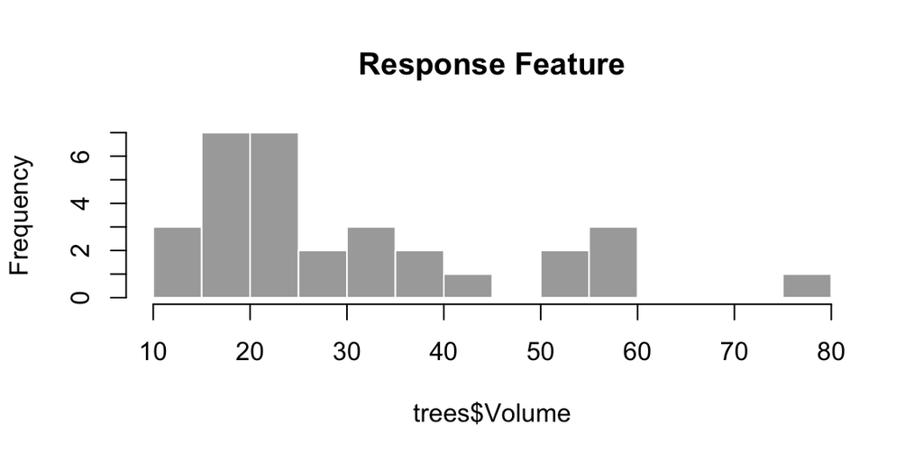

## Scatter Plot

- In 'lm-Plot' tab, the response is plotted on the y-axis and the predictor on the x-axis.

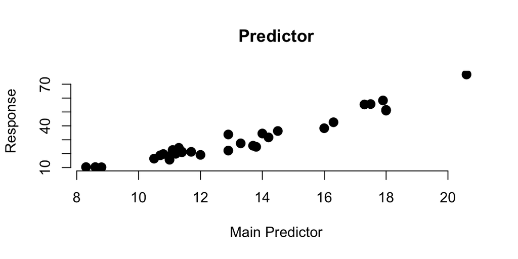

## Regression Model

- Whenever a brushed dataset is selected, a lm line is plotted on the chart.

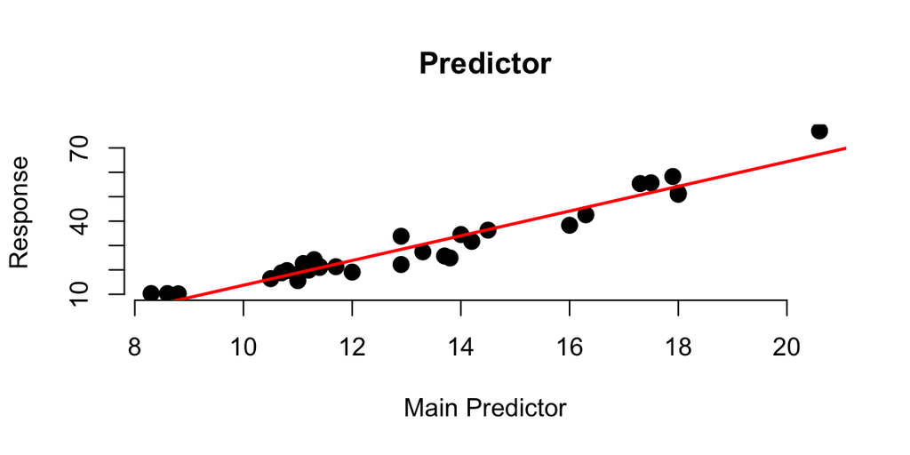